# SI_quant

Horowitz, Mekler, Schneider, Frank, etc. Analyses for Scalar Implicature, Give-Quantifier, and DCCS

Set up Rmd parameters

```r
library(knitr)
opts_chunk$set(cache=TRUE, message=FALSE, warning=FALSE)
```

Preliminaries

```r
rm(list=ls())
library(ggplot2)
library(reshape)
library(dplyr)
library(stringr)
library(tidyr)
library(markdown)
library(directlabels)
library(magrittr)
library(bootstrap)
library(RCurl)
library(readr)


theme_set(theme_bw())
```

SI graphs and visualizations

```r
#reading in the original wide-form dataframe
d1 <- read.csv("../data/SI_coding.csv")

#fill in the selection types for easier analyses
d1 %<>%
  mutate(carrot_selection = factor(carrot_selection, levels=c(1, 2, 3), labels = c("none", "some", "all")),
         hat_selection = factor(hat_selection, levels=c(1, 2, 3), labels = c("all", "some", "none")),
         cookies_selection = factor(cookies_selection, levels=c(1, 2, 3), labels = c("none", "some", "all")),
         trains_selection = factor(trains_selection, levels=c(1, 2, 3), labels = c("none", "all", "some")),
         cats_selection = factor(cats_selection, levels=c(1, 2, 3), labels = c("all", "some", "none")),
         purses_selection = factor(purses_selection, levels=c(1, 2, 3), labels = c("none", "some", "all")),
         keys_selection = factor(keys_selection, levels=c(1, 2, 3), labels = c("none", "some", "all")),
         shirts_selection = factor(shirts_selection, levels=c(1, 2, 3), labels = c("some", "all", "none")),
         breads_selection = factor(breads_selection, levels=c(1, 2, 3), labels = c("all", "some", "none")),
         horses_selection = factor(horses_selection, levels=c(1, 2, 3), labels = c("all", "some", "none")),
         bears_selection= factor(bears_selection, levels=c(1, 2, 3), labels = c("none", "some", "all")),
         frogs_selection = factor(frogs_selection, levels=c(1, 2, 3), labels = c("all", "some", "none")),
         plates_selection = factor(plates_selection, levels=c(1, 2, 3), labels = c("all", "some", "none")),
         books_selection = factor(books_selection, levels=c(1, 2, 3), labels = c("none", "all", "some")),
         elephants_selection = factor(elephants_selection, levels=c(1, 2, 3), labels = c("some", "all", "none")),
         lamps_selection = factor(lamps_selection, levels=c(1, 2, 3), labels = c("none", "all", "some")),
         bananas_selection = factor(bananas_selection, levels=c(1, 2, 3), labels = c("some", "all", "none")),
         butterflies_selection = factor(butterflies_selection, levels=c(1, 2, 3), labels = c("none", "some", "all")))

d2=melt.data.frame(d1,c("sub_ID","test_age", "order", "training"),c("carrot", "hat", "cookies", "trains", "cats", "purses",  "keys", "shirts", "breads", "horses", "bears", "frogs", "plates", "books", "elephants", "lamps", "bananas", "butterflies", "carrot_selection", "hat_selection", "cookies_selection", "trains_selection", "cats_selection", "purses_selection",  "keys_selection", "shirts_selection", "breads_selection", "horses_selection", "bears_selection", "frogs_selection", "plates_selection", "books_selection", "elephants_selection", "lamps_selection", "bananas_selection", "butterflies_selection", "carrot_type", "hat_type", "cookies_type", "trains_type", "cats_type", "purses_type",  "keys_type", "shirts_type", "breads_type", "horses_type", "bears_type", "frogs_type", "plates_type", "books_type", "elephants_type", "lamps_type", "bananas_type", "butterflies_type"))


#making a respectable df
onethird <- (1/3)*nrow(d2)
data <- d2[1:onethird,]
data$selection <- d2$value[(onethird+1):(onethird*2)]
data$type <- d2$value[(2*onethird+1):nrow(d2)]
names(data)[5] <- "item"
names(data)[6] <- "SI_correct"
data$correct <- data$SI_correct==1

#filtering out NAs, adding agesplit
data %<>%
  filter(sub_ID != "", correct != "NA") %>%
  mutate(agesplit = cut(test_age, breaks=c(3, 3.5, 4, 4.5, 5)), agesplit = factor(agesplit,
                           labels=c("3-3.5 years", "3.5-4 years", "4-4.5 years", "4.5-5 years"))) %>%
  filter(agesplit != "NA")

data$type %<>%
  str_replace("control_all", "All")%>%
  str_replace("control_none", "None")%>%
  str_replace("implicature", "Implicature")

data$selection %<>%
  str_replace("all", "All")%>%
  str_replace("none", "None")%>%
  str_replace("some", "Some")

#in case you need this data in the future
data_si <- data %>%
  mutate(test = "Scalar Implicature")
```

SI graphs

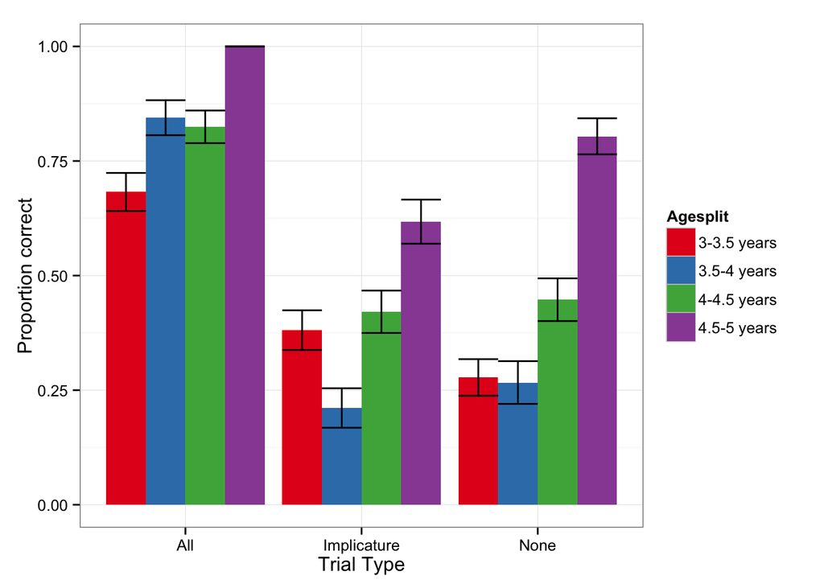

```r
# #number of kids in each age group
# num_kids <- data %>%
#   select(sub_ID, agesplit) %>%
#   distinct() %>%
#   group_by(agesplit)%>%
#   summarize(n=n())


#accuracy by age group in different trials
agg.data <- aggregate(data$correct, list(data$type, data$agesplit), FUN=sum)
agg.data.len <- aggregate(data$correct, list(data$type, data$agesplit), FUN=length)
agg.data$x <- agg.data$x
agg.data.len$x <- agg.data.len$x

names(agg.data) <- c("type", "Agesplit", "correct")
agg.data$total <- agg.data.len$x
agg.data$prop.corr <- agg.data$correct / agg.data$total

#prop correct and standard error
agg.data$q <- 1 - agg.data$prop.corr
agg.data$err <- sqrt((agg.data$prop.corr * agg.data$q) / agg.data$total)

#defining variables
dodge <- position_dodge(width=0.9)
limits <- aes(ymax = prop.corr + err, ymin=prop.corr - err)

#plot
quartz()
ggplot(data = agg.data,
       aes(x=type, y=prop.corr, fill=Agesplit)) +
  geom_bar(stat="identity", position = position_dodge())  + geom_errorbar(limits, position=dodge)+
  ylab("Proportion correct") +
  xlab("Trial Type") +
  scale_fill_brewer(palette="Set1")
```

Okay, what kinds of items are choosing on trials when they get things wrong?

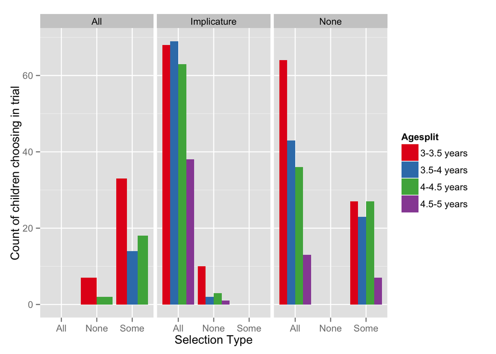

```r
#first, filter out trials where kids got things right
si_wrong <- data %>%
  filter(SI_correct != 1) %>%
  group_by(agesplit, type, selection)%>%
  summarise(n=n())%>%
  dplyr::rename(Agesplit = agesplit) %>%
  mutate(n.total = sum(n), prop = n/n.total)

#now graph
quartz()
ggplot(data = si_wrong,
       aes(x=selection, y=n, fill=Agesplit)) +
  geom_bar(stat="identity", position = position_dodge())  +
  ylab("Count of children choosing in trial") +
  xlab("Selection Type") + facet_wrap(~type) +
  scale_fill_brewer(palette="Set1")
```

GQ analyses

```r
#read in and establish dataframe
d1 <- read.csv("../data/GQ_coding.csv")
d1[,c(8,10,12,14,16,18,20,22, 31, 32, 33, 34)] <- sapply(d1[,c(8,10,12,14,16,18,20,22, 31, 32, 33, 34)],as.character) #for unknown reasons this is necessary for melt.data.frame now


#change to long form
d2=melt.data.frame(d1,c("sub_ID", "test_age","condition", "order", "training"),c("X1_condition", "X2_condition", "X3_condition", "X4_condition", "X5_condition", "X6_condition",  "X7_condition", "X8_condition", "X1_given", "X2_given", "X3_given", "X4_given", "X5_given", "X6_given",  "X7_given", "X8_given", "X1_correct", "X2_correct", "X3_correct", "X4_correct", "X5_correct", "X6_correct",  "X7_correct", "X8_correct"))

#making a respectable df
onethird <- (1/3)*nrow(d2)
data <- d2[1:onethird,]
data$selection <- d2$value[(onethird+1):(onethird*2)]
data$type <- d2$value[(2*onethird+1):nrow(d2)]
names(data)[6] <- "trial"
names(data)[7] <- "prompt"
names(data)[8] <- "num_given"
names(data)[9] <- "GQ_correct"

#filtering data, creating age breaks
data %<>%
  filter(sub_ID != "", num_given != "N/A") %>%
  mutate(agesplit = cut(test_age, breaks=c(3, 3.5, 4, 4.5, 5)), agesplit = factor(agesplit,
                           labels=c("3-3.5 years", "3.5-4 years", "4-4.5 years", "4.5-5 years"))) %>%
  dplyr::rename(Agesplit = agesplit) %>%
  filter(Agesplit != "NA", num_given != "0 (8 oranges)", num_given != "0 (8 bananas)", num_given != "0 (8 strawberries)")

#this is because num_given is a factor - need to change to a number - need to do this for standard error
data$num_given <- as.character(data$num_given)
data$num_given <- as.numeric(data$num_given)
data$GQ_correct <-as.character(data$GQ_correct)
data$GQ_correct <- as.numeric(data$GQ_correct)

data$prompt %<>%
  str_replace("all", "All")%>%
  str_replace("most", "Most")%>%
  str_replace("some", "Some")%>%
  str_replace("none", "None")

#creating dataframe for analyses
data_gq <- data %>%
  mutate(test = "Give-Quantifier")
```

Average given for each prompt by age group

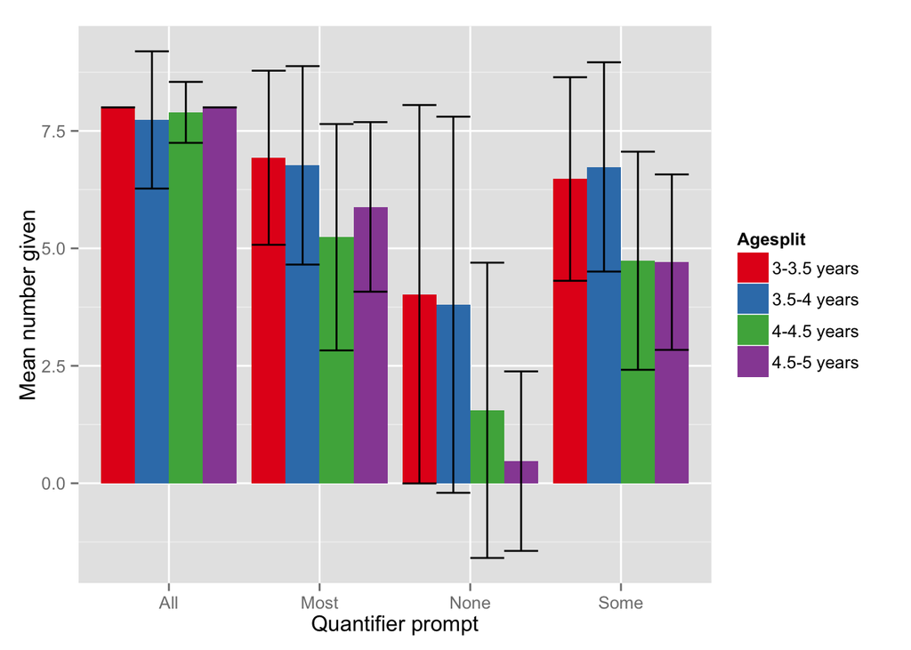

```r
agg.data <- aggregate(data$num_given, list(data$prompt, data$Agesplit), FUN=mean)
agg.data.sd <- aggregate(data$num_given, list(data$prompt, data$Agesplit), FUN=sd)

names(agg.data) <- c("prompt", "Agesplit", "num_given")
agg.data$sd <- agg.data.sd$x

##establish limits
limits <- aes(ymax = num_given + sd, ymin=num_given - sd)

#plot
quartz()
ggplot(data = agg.data,
       aes(x=prompt, y=num_given, fill=Agesplit)) +
  geom_bar(stat="identity", position = position_dodge())  + geom_errorbar(limits, position=dodge)+
  ylab("Mean number given") +
  xlab("Quantifier prompt") +
  scale_fill_brewer(palette="Set1")
```

Correct trials split by age - note, this is just whether kids got the trial correct or not

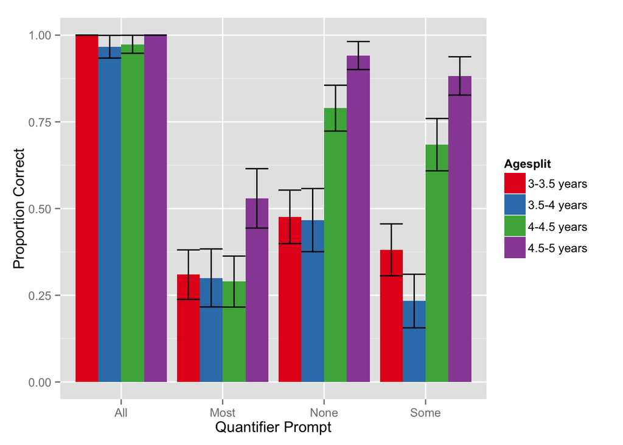

```r
agg.data <- aggregate(data$GQ_correct, list(data$prompt, data$Agesplit), FUN=sum)
agg.data.len <- aggregate(data$GQ_correct, list(data$prompt, data$Agesplit), FUN=length)
agg.data$x <- agg.data$x
agg.data.len$x <- agg.data.len$x

names(agg.data) <- c("prompt", "Agesplit", "correct")
agg.data$total <- agg.data.len$x
agg.data$prop.corr <- agg.data$correct / agg.data$total

#prop correct and standard error
agg.data$q <- 1 - agg.data$prop.corr
agg.data$err <- sqrt((agg.data$prop.corr * agg.data$q) / agg.data$total)

#defining variables
dodge <- position_dodge(width=0.9)
limits <- aes(ymax = prop.corr + err, ymin=prop.corr - err)

#plot
quartz()
ggplot(data = agg.data,
       aes(x=prompt, y=prop.corr, fill=Agesplit)) +
  geom_bar(stat="identity", position = position_dodge())  + geom_errorbar(limits, position=dodge)+
  ylab("Proportion Correct") +
  xlab("Quantifier Prompt") +
  scale_fill_brewer(palette="Set1")
```

Number given (average) Split by four age groups:

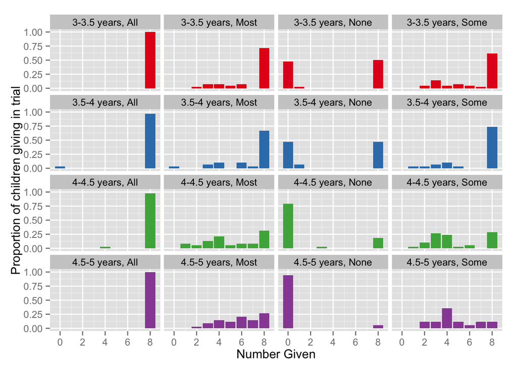

```r
hist_data <- data %>%
  group_by(Agesplit, prompt, num_given)%>%
  summarise(n = n()) %>%
  group_by(Agesplit, prompt) %>%
  mutate(n.total = sum(n), prop = n/n.total)

#plot
quartz()
ggplot(data = hist_data, aes(x = num_given, y = prop, fill = Agesplit)) +
  geom_bar(stat = "identity", position = position_dodge()) +
  xlab("Number Given") +
  ylab("Proportion of children giving in trial") +
  facet_wrap(agesplit~prompt) +
  scale_fill_brewer(palette="Set1") + facet_wrap(Agesplit ~ prompt) + theme(legend.position="none")
```

DCCS

Read in dataframe

```r
#wide-form
d1 <- read.csv("../data/DCCS_coding.csv")
#long form
d2=melt.data.frame(d1,c("sub_ID","test_age","condition", "order"),c("pre_1", "pre_2", "pre_3", "pre_4", "pre_5", "pre_6",  "post_1", "post_2", "post_3", "post_4", "post_5", "post_6"))

#filtering data, creating age breaks
data <- d2 %>%
  filter(sub_ID != "") %>%
  mutate(agesplit = cut(test_age, breaks=c(3, 3.5, 4, 4.5, 5)),
         agesplit = factor(agesplit,labels=c("3-3.5 years", "3.5-4 years", "4-4.5 years", "4.5-5 years")))

#renaming things
names(data)[5] <- "trial_type"
names(data)[6] <- "DCCS_correct"

#df for further analyses
data_dccs <- data
data_dccs$test <- "DCCS"
```

More sensible DCCS graph

```r
tmp1 <- unlist(data$trial_type)%>%
  str_replace("pre_1", "pre")%>%
  str_replace("pre_2", "pre")%>%
  str_replace("pre_3", "pre")%>%
  str_replace("pre_4", "pre")%>%
  str_replace("pre_5", "pre")%>%
  str_replace("pre_6", "pre")%>%
  str_replace("post_1", "post")%>%
  str_replace("post_2", "post")%>%
  str_replace("post_3", "post")%>%
  str_replace("post_4", "post")%>%
  str_replace("post_5", "post")%>%
  str_replace("post_6", "post")

tmp <- as.data.frame(tmp1) %>%
  dplyr::rename(switch_type = tmp1)
tmp2 <- bind_cols(data, tmp)
data <- tmp2

data$switch_type %<>%
  str_replace("post", "Post-switch")%>%
  str_replace("pre", "Pre-switch")
```

Accuracy on DCCS task

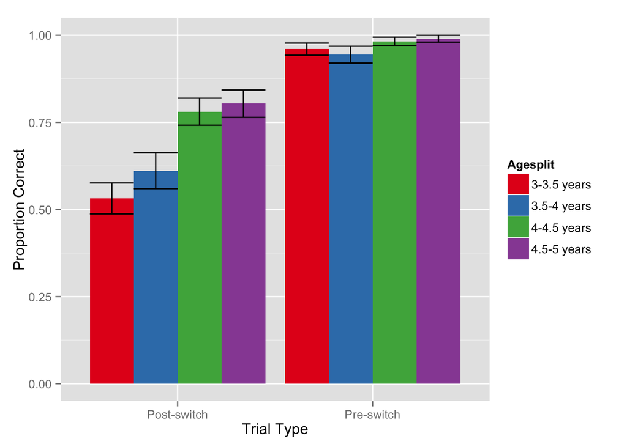

```r
#aggregate correct by trial type and age
agg.data <- aggregate(data$DCCS_correct, list(data$switch_type, data$agesplit), FUN=sum)
agg.data.len <- aggregate(data$DCCS_correct, list(data$switch_type, data$agesplit), FUN=length)
agg.data$x <- agg.data$x
agg.data.len$x <- agg.data.len$x

names(agg.data) <- c("trial_type", "Agesplit", "correct")
agg.data$total <- agg.data.len$x
agg.data$prop.corr <- agg.data$correct / agg.data$total

#standard error
agg.data$q <- 1 - agg.data$prop.corr
agg.data$err <- sqrt((agg.data$prop.corr * agg.data$q) / agg.data$total)

#variables established
dodge <- position_dodge(width=0.9)
limits <- aes(ymax = prop.corr + err, ymin=prop.corr - err)

#plot
quartz()
ggplot(data = agg.data,
       aes(x=trial_type, y=prop.corr, fill=Agesplit)) +
  geom_bar(stat="identity", position = position_dodge())  + geom_errorbar(limits, position=dodge)+
  ylab("Proportion Correct") +
  xlab("Trial Type") +
  scale_fill_brewer(palette="Set1")
```

Stats

Summary measures for each participant

First, SI

```r
#si df
data_si$SI_correct <- as.character(data_si$SI_correct)
data_si$SI_correct <- as.numeric(data_si$SI_correct)

#scalar implicature task
mss.acc <- data_si %>%
  group_by(sub_ID, type)%>%
  summarise(correct=mean(SI_correct))%>%
  spread(type, correct)
```

Now DCCS

```r
#this is a terrible and horrible thing that I had to do in order to get the data formatted correctly
tmp1 <- unlist(data_dccs$trial_type)%>%
  str_replace("pre_1", "pre")%>%
  str_replace("pre_2", "pre")%>%
  str_replace("pre_3", "pre")%>%
  str_replace("pre_4", "pre")%>%
  str_replace("pre_5", "pre")%>%
  str_replace("pre_6", "pre")%>%
  str_replace("post_1", "post")%>%
  str_replace("post_2", "post")%>%
  str_replace("post_3", "post")%>%
  str_replace("post_4", "post")%>%
  str_replace("post_5", "post")%>%
  str_replace("post_6", "post")
```

```r
#seriously, this is so terrible
tmp <- as.data.frame(tmp1) %>%
  dplyr::rename(switch_type = tmp1)
tmp2 <- bind_cols(data_dccs, tmp)
data_dccs <- tmp2
```

```r
#dccs task summary measures by participant
mss.acc2 <- data_dccs %>%
  group_by(sub_ID, switch_type)%>%
  summarise(correct=mean(DCCS_correct))%>%
  spread(switch_type, correct)
```

Now GQ

```r
#gq task - note that some of these are NAs because the kids gave 0 of the named fruit, but 8 of another fruit
#first mean number
mss.acc3 <- data_gq %>%
  group_by(sub_ID, prompt)%>%
  summarise(mean_num = mean(num_given),
            test_age = test_age[1]) %>%
  spread(prompt, mean_num)

#then correct
mss.acc4 <- data_gq %>%
  group_by(sub_ID, prompt)%>%
  summarise(mean_correct = mean(GQ_correct))%>%
  spread(prompt, mean_correct)
```

Create a wide-form df on which to run analyses - note that these are the mean performances across all trials per participant

```r
#this is joining the summary measures we created above, and renaming the variables so that we keep everything straight
tmp <- right_join(mss.acc, mss.acc2, by = "sub_ID")
tmp1 <- right_join(tmp, mss.acc3, by = "sub_ID")
d_all <- right_join(tmp1, mss.acc4, by = "sub_ID") %>%
  dplyr::rename(SI_none = None.x,
         SI_all = All.x,
         SI_implicature = Implicature,
         DCCS_post = post, DCCS_pre = pre,
         GQ_all = All.y,
         GQ_most = Most.x,
         GQ_some = Some.x,
         GQ_none = None.y,
         GQ_all_correct = All,
         GQ_most_correct = Most.y,
         GQ_some_correct = Some.y,
         GQ_none_correct = None)
```

Simple Correlations

Huge correlation matrix of all variables

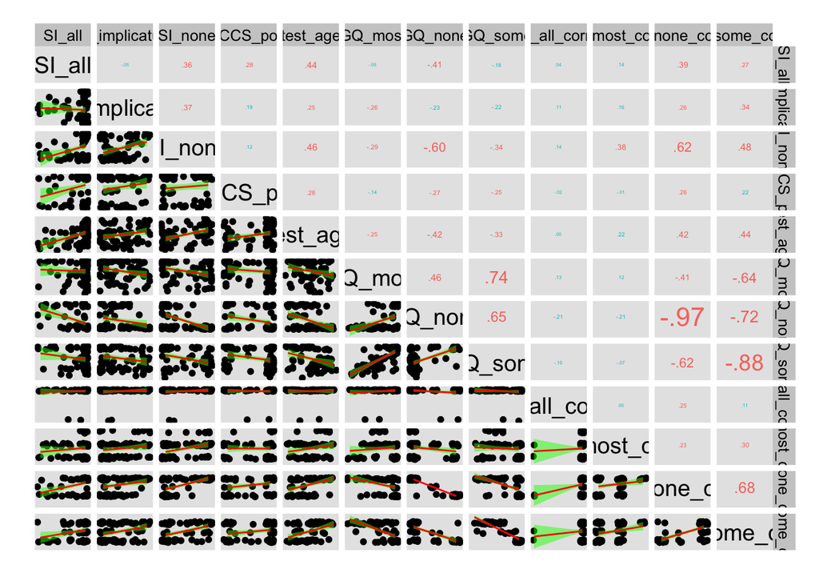

```r
source("ggcorplot.R")

d_all$GQ_none[is.na(d_all$GQ_none)] <- 0 # backfill when they gave the wrong object (but none of the target)
cor.data <- d_all %>%
  dplyr::select(-sub_ID, -GQ_all, -DCCS_pre) %>%
  filter(complete.cases(.)) %>%
  data.frame

quartz()
ggcorplot(data=cor.data)
```

Partial correlations - control for age First, Scalar Implicature with DCCS and SI

```r
library(ppcor)
#partial correlation - implicature and dccs
pcor.test(d_all$SI_implicature, d_all$DCCS_post, d_all$test_age)
```

```
##    estimate   p.value statistic  n gp  Method
## 1 0.1346409 0.2590293  1.128688 72  1 pearson
```

```r
#Significant correlation between performance on implicature and none trials in SI task after controlling for age
pcor.test(d_all$SI_implicature, d_all$SI_none, d_all$test_age)
```

```
##    estimate   p.value statistic  n gp  Method
## 1 0.2968448 0.0098182  2.582167 72  1 pearson
```

```r
pcor.test(d_all$SI_none, d_all$DCCS_post, d_all$test_age)
```

```
##      estimate   p.value   statistic  n gp  Method
## 1 -0.01113143 0.9263244 -0.09247033 72  1 pearson
```

Then GQ with DCCS and GQ

```r
pcor.test(d_all$GQ_none, d_all$DCCS_post, d_all$test_age)
```

```
##     estimate   p.value statistic  n gp  Method
## 1 -0.1798045 0.1289355 -1.518313 72  1 pearson
```

```r
pcor.test(d_all$GQ_some, d_all$DCCS_post, d_all$test_age)
```

```
##     estimate   p.value statistic  n gp  Method
## 1 -0.1783167 0.1322379 -1.505335 72  1 pearson
```

```r
#highly significant correlation between performance on GQ none and some trials, controlling for age
pcor.test(d_all$GQ_none, d_all$GQ_some, d_all$test_age)
```

```
##    estimate      p.value statistic  n gp  Method
## 1 0.5982933 5.562805e-10  6.202345 72  1 pearson
```

Finally GQ with SI

```r
pcor.test(d_all$SI_implicature, d_all$GQ_some, d_all$test_age)
```

```
##     estimate   p.value statistic  n gp  Method
## 1 -0.1525099 0.1998997 -1.281837 72  1 pearson
```

```r
#almost signficant negative correlation between SI_none performance and GQ_some, controlling for age. This means that kids who do worse on the SI_none tasks are more likely to give more items for GQ_some (aka give 8 items for some)
pcor.test(d_all$SI_none, d_all$GQ_some, d_all$test_age)
```

```
##     estimate   p.value statistic  n gp  Method
## 1 -0.2265543 0.0533423 -1.932139 72  1 pearson
```

```r
pcor.test(d_all$SI_implicature, d_all$GQ_none, d_all$test_age)
```

```
##     estimate   p.value statistic  n gp  Method
## 1 -0.1421088 0.2330468 -1.192547 72  1 pearson
```

```r
#very significant negative correlation between performance on SI_none and GQ_none, meaning that kids who do worse on SI_none are more likely to give all 8 objects for none
pcor.test(d_all$SI_none, d_all$GQ_none, d_all$test_age)
```

```
##     estimate    p.value statistic  n gp  Method
## 1 -0.5029383 1.3414e-06  -4.83352 72  1 pearson
```

Partial correlations for GQ_correct with everything

```r
#first scalar implicature

#significant correlation between getting GQ some and SI implicature trials correct
pcor.test(d_all$GQ_some_correct, d_all$SI_implicature, d_all$test_age)
```

```
##    estimate    p.value statistic  n gp  Method
## 1 0.2690276 0.02032718  2.320253 72  1 pearson
```

```r
#significant correlation between getting GQ none and SI none correct
pcor.test(d_all$GQ_none_correct, d_all$SI_none, d_all$test_age)
```

```
##    estimate      p.value statistic  n gp  Method
## 1 0.5246767 3.062451e-07  5.119563 72  1 pearson
```

```r
#significant between GQ some and SI none
pcor.test(d_all$GQ_some_correct, d_all$SI_none, d_all$test_age)
```

```
##    estimate     p.value statistic  n gp  Method
## 1 0.3485984 0.002005126  3.089472 72  1 pearson
```

```r
pcor.test(d_all$GQ_none_correct, d_all$SI_implicature, d_all$test_age)
```

```
##    estimate   p.value statistic  n gp  Method
## 1 0.1768977 0.1354455  1.492968 72  1 pearson
```

```r
#now DCCS
pcor.test(d_all$GQ_some_correct, d_all$DCCS_post, d_all$test_age)
```

```
##    estimate   p.value statistic  n gp  Method
## 1 0.1123897 0.3474577  0.939532 72  1 pearson
```

```r
pcor.test(d_all$GQ_none_correct, d_all$DCCS_post, d_all$test_age)
```

```
##    estimate   p.value statistic  n gp  Method
## 1 0.1612308 0.1747691  1.357038 72  1 pearson
```

Summary of partial correlations: After controlling for age, we find significant correlations between:

SI none and SI implicature this means that kids who get SI implicature trials correct are also more likely to get SI none trials correct

GQ some and GQ none trials similar to above

Si none and GQ none negative correlation, meaning that kids who do worse on SInone trials are more likely to fail GQnone trials - scored as correct, they are highly correlated

GQ some and SI implicature trials correlated (when scored as correct)

And GQ some trials and SI none trials also correlated (when scored as correct)

Linear Models

Try predicting none on the basis of control.

```r
summary(glm(SI_none ~  DCCS_post, data=d_all,
            family = "binomial"))
```

```
##
## Call:
## glm(formula = SI_none ~ DCCS_post, family = "binomial", data = d_all)
##
## Deviance Residuals:
##     Min       1Q   Median       3Q      Max
## -1.1484  -1.0976  -0.2499   1.2067   1.4218
##
## Coefficients:
##             Estimate Std. Error z value Pr(>|z|)
## (Intercept)  -0.5583     0.4516  -1.236    0.216
## DCCS_post     0.4896     0.5542   0.884    0.377
##
## (Dispersion parameter for binomial family taken to be 1)
##
##     Null deviance: 74.138  on 71  degrees of freedom
## Residual deviance: 73.345  on 70  degrees of freedom
## AIC: 101.34
##
## Number of Fisher Scoring iterations: 3
```

```r
summary(glm(SI_none ~  GQ_none_correct + test_age, data=d_all,
            family = "binomial"))
```

```
##
## Call:
## glm(formula = SI_none ~ GQ_none_correct + test_age, family = "binomial",
##     data = d_all)
##
## Deviance Residuals:
##      Min        1Q    Median        3Q       Max
## -1.79761  -0.48717  -0.09781   0.73231   1.81231
##
## Coefficients:
##                 Estimate Std. Error z value Pr(>|z|)
## (Intercept)      -6.4010     2.2657  -2.825  0.00473 **
## GQ_none_correct   2.8739     0.9049   3.176  0.00149 **
## test_age          1.0064     0.5650   1.781  0.07489 .
## ---
## Signif. codes:  0 '***' 0.001 '**' 0.01 '*' 0.05 '.' 0.1 ' ' 1
##
## (Dispersion parameter for binomial family taken to be 1)
##
##     Null deviance: 74.138  on 71  degrees of freedom
## Residual deviance: 46.302  on 69  degrees of freedom
## AIC: 71.653
##
## Number of Fisher Scoring iterations: 5
```

```r
summary(glm(GQ_none_correct == 0 ~  DCCS_post, data=d_all,
            family = "binomial"))
```

```
##
## Call:
## glm(formula = GQ_none_correct == 0 ~ DCCS_post, family = "binomial",
##     data = d_all)
##
## Deviance Residuals:
##     Min       1Q   Median       3Q      Max
## -1.1109  -0.7294  -0.7294   1.2454   1.7055
##
## Coefficients:
##             Estimate Std. Error z value Pr(>|z|)
## (Intercept)  -0.1584     0.4395  -0.360   0.7185
## DCCS_post    -1.0299     0.5771  -1.785   0.0743 .
## ---
## Signif. codes:  0 '***' 0.001 '**' 0.01 '*' 0.05 '.' 0.1 ' ' 1
##
## (Dispersion parameter for binomial family taken to be 1)
##
##     Null deviance: 88.632  on 71  degrees of freedom
## Residual deviance: 85.434  on 70  degrees of freedom
## AIC: 89.434
##
## Number of Fisher Scoring iterations: 4
```

```r
summary(glm(GQ_none_correct == 0 ~  DCCS_post + test_age, data=d_all,
            family = "binomial"))
```

```
##
## Call:
## glm(formula = GQ_none_correct == 0 ~ DCCS_post + test_age, family = "binomial",
##     data = d_all)
##
## Deviance Residuals:
##     Min       1Q   Median       3Q      Max
## -1.4459  -0.7938  -0.5404   1.0110   2.1854
##
## Coefficients:
##             Estimate Std. Error z value Pr(>|z|)
## (Intercept)   5.0735     2.0786   2.441   0.0147 *
## DCCS_post    -0.6301     0.6250  -1.008   0.3134
## test_age     -1.4195     0.5548  -2.559   0.0105 *
## ---
## Signif. codes:  0 '***' 0.001 '**' 0.01 '*' 0.05 '.' 0.1 ' ' 1
##
## (Dispersion parameter for binomial family taken to be 1)
##
##     Null deviance: 88.632  on 71  degrees of freedom
## Residual deviance: 77.974  on 69  degrees of freedom
## AIC: 83.974
##
## Number of Fisher Scoring iterations: 4
```

Try predicting some on the basis of control

```r
summary(glm(GQ_some_correct ~  DCCS_post + test_age, data=d_all,
            family = "binomial"))
```

```
##
## Call:
## glm(formula = GQ_some_correct ~ DCCS_post + test_age, family = "binomial",
##     data = d_all)
##
## Deviance Residuals:
##     Min       1Q   Median       3Q      Max
## -1.9144  -0.9534   0.4842   0.8931   1.8059
##
## Coefficients:
##             Estimate Std. Error z value Pr(>|z|)
## (Intercept)  -6.4049     2.0307  -3.154  0.00161 **
## DCCS_post     0.5271     0.6097   0.864  0.38733
## test_age      1.5883     0.5227   3.039  0.00237 **
## ---
## Signif. codes:  0 '***' 0.001 '**' 0.01 '*' 0.05 '.' 0.1 ' ' 1
##
## (Dispersion parameter for binomial family taken to be 1)
##
##     Null deviance: 86.655  on 71  degrees of freedom
## Residual deviance: 72.857  on 69  degrees of freedom
## AIC: 92.322
##
## Number of Fisher Scoring iterations: 3
```

Also try a super exploratory analysis where we put together none kids

```r
d_all <- d_all %>%
  mutate(SI_wrong = ((SI_none + SI_implicature)/2) < 1) %>%
  mutate(none_composite = ((as.numeric(GQ_none==0) + SI_none)/2) > .5)

summary(glm(none_composite ~ test_age + DCCS_post, data=d_all,
            family = "binomial"))
```

```
##
## Call:
## glm(formula = none_composite ~ test_age + DCCS_post, family = "binomial",
##     data = d_all)
##
## Deviance Residuals:
##     Min       1Q   Median       3Q      Max
## -1.9580  -0.9534   0.5461   1.0126   1.8359
##
## Coefficients:
##             Estimate Std. Error z value Pr(>|z|)
## (Intercept)  -6.9369     2.0623  -3.364 0.000769 ***
## test_age      1.7361     0.5311   3.269 0.001080 **
## DCCS_post     0.2057     0.6178   0.333 0.739210
## ---
## Signif. codes:  0 '***' 0.001 '**' 0.01 '*' 0.05 '.' 0.1 ' ' 1
##
## (Dispersion parameter for binomial family taken to be 1)
##
##     Null deviance: 99.758  on 71  degrees of freedom
## Residual deviance: 85.257  on 69  degrees of freedom
## AIC: 91.257
##
## Number of Fisher Scoring iterations: 4
```

```r
summary(glm(none_composite ~  DCCS_post, data=d_all,
            family = "binomial"))
```

```
##
## Call:
## glm(formula = none_composite ~ DCCS_post, family = "binomial",
##     data = d_all)
##
## Deviance Residuals:
##    Min      1Q  Median      3Q     Max
## -1.300  -1.300   1.060   1.060   1.363
##
## Coefficients:
##             Estimate Std. Error z value Pr(>|z|)
## (Intercept)  -0.4269     0.4446  -0.960    0.337
## DCCS_post     0.7107     0.5501   1.292    0.196
##
## (Dispersion parameter for binomial family taken to be 1)
##
##     Null deviance: 99.758  on 71  degrees of freedom
## Residual deviance: 98.058  on 70  degrees of freedom
## AIC: 102.06
##
## Number of Fisher Scoring iterations: 4
```

```r
summary(glm(none_composite ~ test_age + DCCS_post, data=d_all,
            family = "binomial"))
```

```
##
## Call:
## glm(formula = none_composite ~ test_age + DCCS_post, family = "binomial",
##     data = d_all)
##
## Deviance Residuals:
##     Min       1Q   Median       3Q      Max
## -1.9580  -0.9534   0.5461   1.0126   1.8359
##
## Coefficients:
##             Estimate Std. Error z value Pr(>|z|)
## (Intercept)  -6.9369     2.0623  -3.364 0.000769 ***
## test_age      1.7361     0.5311   3.269 0.001080 **
## DCCS_post     0.2057     0.6178   0.333 0.739210
## ---
## Signif. codes:  0 '***' 0.001 '**' 0.01 '*' 0.05 '.' 0.1 ' ' 1
##
## (Dispersion parameter for binomial family taken to be 1)
##
##     Null deviance: 99.758  on 71  degrees of freedom
## Residual deviance: 85.257  on 69  degrees of freedom
## AIC: 91.257
##
## Number of Fisher Scoring iterations: 4
```